# Project 6: Randomization and Matching

[figure not shown]

[output not shown]

[output cut: 89 more lines]

[output not shown]

```r
# Set the number of simulations
n_simulations <- 1000

# Create an empty matrix to store simulation results
sim_results <- matrix(NA, nrow = n_simulations, ncol = 2)

# Perform Monte Carlo simulation
for (i in 1:n_simulations) {
  # Generate treatment assignment vector
  ndf <- ypsps %>%
    select(interviewid, student_Gen) %>%
    mutate(treatment = as.numeric(sample(c(0, 1), length(unique(interviewid)), replace = TRUE, prob = c(0.5, 0.5))))

  # Calculate the proportion of treatment units
  proportion_treatment <- sum(ndf$treatment) / length(unique(ndf$interviewid))

  # Calculate the proportion of females in the treatment group
  proportion_female <- sum(ndf$student_Gen[ndf$treatment == 1]) / sum(ndf$treatment)

  # Store the results
  sim_results[i, 1] <- proportion_treatment
  sim_results[i, 2] <- proportion_female
}

# Set up the plotting area
par(mfrow = c(1, 2)) # Arrange plots in one row and two columns

# Plot histogram of treatment proportions
hist(sim_results[, 1], breaks = 30, main = "Treatment Proportions",
     xlab = "Proportion of Treatment", ylab = "Frequency", col = "pink")

# Plot histogram of female gender in the treatment group
hist(sim_results[, 2], breaks = 30, main = "Female Gender in Treatment Group",
     xlab = "Proportion of Female", ylab = "Frequency", col = "purple")
```

```r
#estimate the ATT using linear regression
match_exact_att_data <- match.data(match_exact_att)

#specify model
lm_full_att <- lm(student_ppnscal ~ college + student_GPA + student_Race + parent_EducHH + parent_Employ + parent_HHCollegePlacebo + parent_Race + parent_ChurchOrg, data = match_exact_att_data, weights = weights)

#summarize results
lm_full_att_summ <- summary(lm_full_att)

#calculate ATT
ATT_full <- lm_full_att_summ$coefficients["college","Estimate"]
ATT_full
```

```
## [1] 1.012418
```

The estimated ATT is approximately 1.0124 which suggests that on average the treatment group (college) scores around 1.0124 units higher on student_ppnscal compared to the control group, after accounting for the effects of all the covariates included in the linear regression model.

## Simulations

```r
# Remove post-treatment covariates
post_vars <- c(colnames(ypsps)[1:11], colnames(ypsps)[123:174])

prevars_df <- ypsps %>%
  select(-(c(post_vars, parent_GPHighSchoolPlacebo, parent_HHCollegePlacebo))) %>%
  filter(complete.cases(.))
pre_vars <- colnames(prevars_df)
result_matrix <- matrix(nrow = 100, ncol = 2)
colnames(result_matrix) <- c("ATT", "Proportion")

# Simulate random selection of features 10k+ times
for (i in 1:100) {
  # Randomly select the number of covariates
  num_covariates <- sample(1:length(pre_vars), 1)

  # Randomly choose covariates
  random_covariates <- sample(pre_vars, num_covariates)

  # Select the random columns
  df <- ypsps %>%
    select(interviewid, college, student_ppnscal, all_of(random_covariates))

  # Fit the propensity score model (assuming glm for simplicity)
  model <- glm(as.formula(paste("college ~", paste(random_covariates, collapse = "+"))), data = ypsps, family = binomial())

  # Step 3: Calculate ATT
  # Match treated and control units
  match_att <- matchit(as.formula(paste("college ~", paste(random_covariates, collapse = "+"))), data = ypsps, family = binomial(), estimand = "ATT")

  # Report the overall balance and the proportion of covariates that meet the balance threshold
  att_summ <- summary(match_att, un = F)
  st_diffs_true_index <- as.numeric(which(abs(att_summ$sum.matched[, "Std. Mean Diff."]) <= 0.1))
  proportion_true <- length(st_diffs_true_index) / length(random_covariates)

  # Estimate the ATT using linear regression
  match_att_data <- match.data(match_att)

  # Specify model
  lm_full_att <- lm(as.formula(paste("student_ppnscal ~", paste("college", paste(random_covariates, collapse = " + "), sep = " + "))), data = match_att_data, weights = weights)

  # Summarize results
  lm_att_summ <- summary(lm_full_att)

  # Calculate ATT
  ATT <- lm_att_summ$coefficients["college", "Estimate"]

  # Store the results in the result matrix
  result_matrix[i, ] <- c(ATT, proportion_true)
}
```

[output not shown]

[output cut: 44 more lines]

[output not shown]

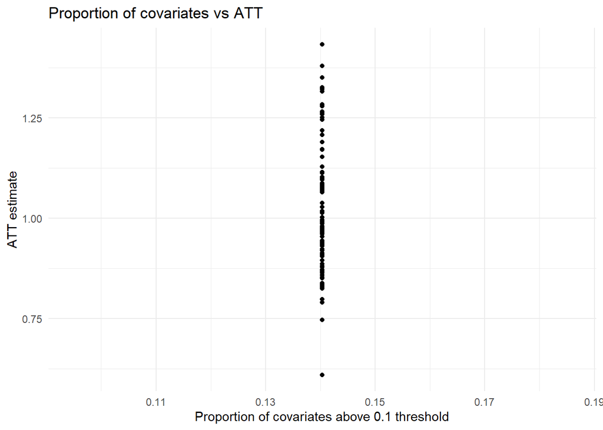

```r
# Fit p-score models and save ATTs, proportion of balanced covariates, and mean percent balance improvement

# Plot ATT v. proportion
result_df <- as.data.frame(result_matrix)
subsample_df <- result_df[sample(nrow(result_df), 100), ]
ggplot(subsample_df, aes(proportion_true, ATT)) +
  geom_point() +
  scale_fill_gradient(low = "lightblue", high = "darkblue") +
  labs(title = "Proportion of covariates vs ATT", x = "Proportion of covariates above 0.1 threshold", y = "ATT estimate") +
  theme_minimal()
```

```r
# 10 random covariate balance plots using gridExtra
random_indices <- sample(1:100, 10, replace = FALSE)
grid_plots <- lapply(random_indices, function(index) {
  # Get the random covariate selection and create the matching model
  random_covariates <- sample(pre_vars, sample(1:length(pre_vars), 1))
  match_att <- matchit(as.formula(paste("college ~", paste(random_covariates, collapse = "+"))), data = ypsps, family = binomial(), estimand = "ATT")

  # Get the matched data
  match_att_data <- match.data(match_att)

  # Plot covariate balance
  ggplot(match_att_data, aes(x = college, y = student_ppnscal, colour = college)) +
    geom_boxplot() +
    facet_wrap(~.match.group, scales = "free") +
    labs(title = paste("Covariate Balance for Random Selection", index), x = "College", y = "Student_ppnscal") +
    theme_minimal()
})
# Arrange plots using gridExtra
#grid.arrange(grobs = grid_plots, ncol = 2) is this working?



# 10 random covariate balance plots (hint try gridExtra)
# Note: ggplot objects are finnicky so ask for help if you're struggling to automatically create them; consider using functions!
```

```r
# Initialize a counter to track the number of simulations with higher proportion of balanced covariates
higher_balance_count <- 0

# Loop through the result matrix to compare proportions
for (i in 2:100) {
  # Check if the proportion of balanced covariates in the current simulation is higher than the previous one
  if (result_matrix[i, "Proportion"] > result_matrix[i - 1, "Proportion"]) {
    higher_balance_count <- higher_balance_count + 1
  }
}

# Output the count of simulations with higher proportion of balanced covariates
print(paste("Number of simulations with higher proportion of balanced covariates:", higher_balance_count))
```

```
## [1] "Number of simulations with higher proportion of balanced covariates: 51"
```

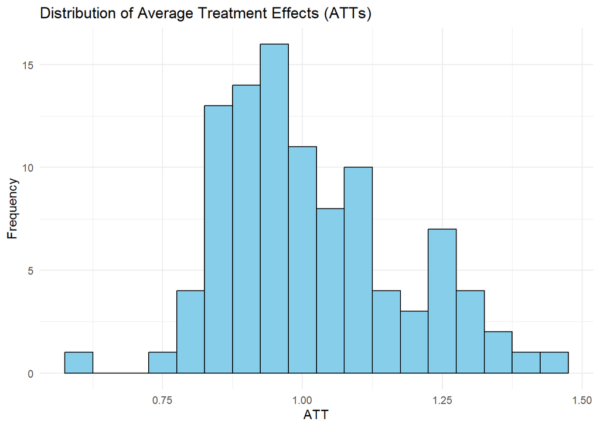

```r
# Plot a histogram of ATTs
ggplot(result_df, aes(x = ATT)) +
  geom_histogram(binwidth = 0.05, fill = "skyblue", color = "black") +
  labs(title = "Distribution of Average Treatment Effects (ATTs)", x = "ATT", y = "Frequency") +
  theme_minimal()
```

```r
mean(ATT)
```

```
## [1] 0.8785397
```

```r
# Install and load the psych package
#install.packages("psych")
library(psych)
# Descriptive statistics
desc <- describe(result_df$ATT)

# Extract skewness, kurtosis, mean, median, and standard deviation from the output
skewness_att <- desc[5, "skew"]
kurtosis_att <- desc[5, "kurtosis"]
mean_att <- desc[1, "mean"]
median_att <- desc[1, "median"]
sd_att <- desc[1, "sd"]

# Print the results
cat("Descriptive Statistics:\n")
```

```
## Descriptive Statistics:
```

```r
print(desc)
```

```
##    vars   n mean   sd median trimmed  mad  min  max range skew kurtosis   se
## X1    1 100 1.01 0.16   0.98       1 0.15 0.61 1.43  0.82 0.48    -0.33 0.02
```

```r
cat("\n")
```

```r
cat("Additional Statistics:\n")
```

```
## Additional Statistics:
```

```r
cat(paste("Mean ATT:", mean_att, "\n"))
```

```
## Mean ATT: 1.0149970768393
```

```r
cat(paste("Median ATT:", median_att, "\n"))
```

```
## Median ATT: 0.978025465136699
```

```r
cat(paste("Standard Deviation of ATT:", sd_att, "\n"))
```

```
## Standard Deviation of ATT: 0.161789525573222
```

```r
cat(paste("Skewness of ATT:", skewness_att, "\n"))
```

```
## Skewness of ATT: NA
```

```r
cat(paste("Kurtosis of ATT:", kurtosis_att, "\n"))
```

```
## Kurtosis of ATT: NA
```

```r
cat("\n")
```

# Matching Algorithm of Your Choice

## Simulate Alternative Model: Nearest Neighbor

```r
# Step 2: Drop post-treatment variables using dplyr
prevars_df <- ypsps %>%
  select(-(c(post_vars, parent_GPHighSchoolPlacebo, parent_HHCollegePlacebo))) %>%
  filter(complete.cases(.))

# define the prevars column names
pre_vars <- colnames(prevars_df)

result_matrix <- matrix(nrow = 100, ncol = 2)
colnames(result_matrix) <- c("ATT", "Proportion")

for (i in 1:100) {
  # Randomly select the number of covariates
  num_covariates <- sample(1:length(pre_vars), 1)

  # Randomly choose covariates
  random_covariates <- sample(pre_vars, num_covariates)

  # Select the random columns
  df <- ypsps %>%
    select(interviewid, college, student_ppnscal, all_of(random_covariates))

  # Fit the propensity score model using KNN matching
  match_knn_att <- matchit(as.formula(paste("college ~", paste(random_covariates, collapse = "+"))),
                           data = df,
                           method = "nearest",
                           distance = "glm",
                           link = "logit",
                           discard = "control",
                           replace = FALSE,
                           ratio = 2)

  # Calculate ATT using KNN matching
  ATT <- summary(match_knn_att)$estimates$ATT

  # Calculate the proportion of covariates that meet the balance threshold
  att_summ <- summary(match_knn_att, un=F)
  st_diffs_true_index <- as.numeric(which(abs(att_summ$sum.matched[, "Std. Mean Diff."]) <= 0.1))
  proportion_true <- length(st_diffs_true_index) / length(random_covariates)

  # Store the results in the result matrix
  result_matrix[i, ] <- c(ATT, proportion_true)
}
```

[output not shown]

[output cut: 45 more lines]

[output not shown]

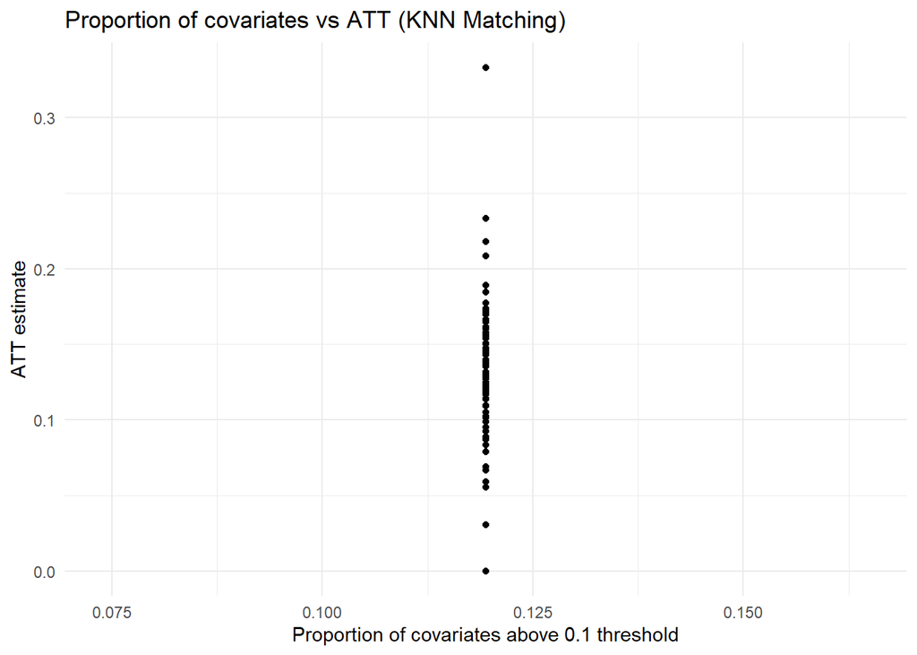

```r
# Plot ATT v. proportion
result_df <- as.data.frame(result_matrix)
subsample_df <- result_df[sample(nrow(result_df), 100), ]
ggplot(subsample_df, aes(proportion_true, ATT)) +
  geom_point() +
  scale_fill_gradient(low = "lightblue", high = "darkblue") +
  labs(title = "Proportion of covariates vs ATT (KNN Matching)",
       x = "Proportion of covariates above 0.1 threshold",
       y = "ATT estimate") +
  theme_minimal()
```

```r
library(gridExtra)
```

```r
# Simulate random selection of features 10k+ times
balance_plots <- list()

for (i in 1:10) {
  # Randomly select the number of covariates
  num_covariates <- sample(1:length(pre_vars), 1)

  # Randomly choose covariates
  random_covariates <- sample(pre_vars, num_covariates)

  # Select the random columns
  df <- ypsps %>%
    select(interviewid, college, student_ppnscal, all_of(random_covariates))

  # Fit the propensity score model using KNN matching
  match_knn_att <- matchit(as.formula(paste("college ~", paste(random_covariates, collapse = "+"))),
                           data = df,
                           method = "nearest",
                           distance = "glm",
                           link = "logit",
                           discard = "control",
                           replace = FALSE,
                           ratio = 2)

  # Save matched data
  matched_data <- match.data(match_knn_att)

  # Create balance plots for matched covariates
  balance_plot <- bal.plot(match_knn_att)

  # Store balance plot in the list
  balance_plots[[i]] <- balance_plot
}
```

```
## No `var.name` was provided. Displaying balance for distance.
```

```
## No `var.name` was provided. Displaying balance for distance.
```

```
## No `var.name` was provided. Displaying balance for distance.
```

```
## No `var.name` was provided. Displaying balance for distance.
```

```
## No `var.name` was provided. Displaying balance for distance.
```

```
## No `var.name` was provided. Displaying balance for distance.
```

```
## No `var.name` was provided. Displaying balance for distance.
```

```
## No `var.name` was provided. Displaying balance for distance.
```

```
## No `var.name` was provided. Displaying balance for distance.
```

```
## No `var.name` was provided. Displaying balance for distance.
```

[figure not shown]

```r
# Arrange balance plots using gridExtra
grid.arrange(grobs = balance_plots, ncol = 2)
```

[output not shown]